# Corrección de color usando una tarjeta de referencia

En este tutorial vamos a ver cómo ajustar el color de una imagen con la clase `ColorCorrection`.

```python
# Session details:
import traitly
from datetime import datetime

print(f"Traitly version used in this tutorial: {traitly.__version__}")
print(f"Run date: {datetime.now():%Y-%m-%d %H:%M}")
```

```
Traitly version used in this tutorial: 0.2.0
Run date: 2026-10-05 21:33
```

A partir de la versión 0.2.0 de Traitly se incluye una nueva clase para corregir el color de una imagen cuando se cuenta con una tarjeta de color de 24 parches. Este proceso es independiente de las clases `FruitInternalAnalyzer` y `FruitExternalAnalyzer`, por lo que se pueden corregir imágenes que no incluyan frutos, siempre y cuando se vea la tarjeta. Aun así, conservamos la lógica y los nombres de los métodos entre las tres clases, por motivos de reproducibilidad y claridad.

El primer paso es importar la clase principal y cargar la imagen que vamos a analizar con `load_image()`.

```python
from traitly.color_correction import ColorCorrection
```

[figure not shown]

```python
path = "/Users/alejandra/Documents/traitly-tutorials/color_correction/cnj0823312.jpg"

cc = ColorCorrection(path)
cc.load_image()
```

Después detectamos la tarjeta de color dentro de la imagen con `detect_color_checker()`. Para este paso no importan el fondo ni el contenido de la imagen, siempre y cuando se incluya una tarjeta Macbeth de 24 parches. La detección es independiente de la orientación e incluso la tarjeta puede estar ligeramente inclinada, aunque para mejores resultados se recomienda que se vea lo más nítida posible. Si hay varias tarjetas en una misma imagen, de momento solo se usa una: la primera que detecta OpenCV.

Una vez detectada, se extrae el color promedio de cada parche y se guarda internamente en el espacio de color LAB.

```
=======================================================
★ COLOR CARD:
=======================================================
> Color checker detected:
    - Coordinates: x1=4299, y1=190, x2=5088, y2=1331
```

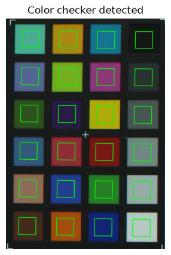

```python
cc.detect_color_checker(plot = True)
```

Ahora aplicamos la corrección con `apply_color_correction()`. La meta es ajustar los colores detectados de los 24 parches a los valores de referencia LAB D65 de la tarjeta (derivados de los datos de X-Rite). Para esto, los valores L, a y b detectados se expanden en términos polinomiales (incluyendo sus interacciones) y con ellos se ajusta un modelo de regresión por mínimos cuadrados parciales (PLSR) para cada canal L, a y b. De esta forma, la luminosidad (L) y el chroma (a y b) se corrigen con modelos separados. El grado del polinomio se indica con `degree`.

Entre mayor sea el grado, más términos tiene el modelo y por tanto podemos capturar interacciones más complejas. Sin embargo, al tener solo 24 parches también corremos el riesgo de sobreajustar. Por eso `apply_color_correction()` te permite indicar el número de componentes del PLSR que se van a usar, mediante el argumento `num_components`.

Ajustar los modelos es rápido, pero aplicar la corrección a todos los píxeles de la imagen puede tardar algunos segundos. Una vez finalizada, se despliegan los resultados, donde puedes ver la imagen original y la imagen corregida. En este ejemplo, nuestra imagen original es algo oscura y los frutos se ven ligeramente verdes. Al corregir, los frutos se muestran de un color más cálido y más realista, y los blancos se ajustan, como se puede ver en el blanco de la tira de círculos y en el parche blanco de la tarjeta.

```
The history saving thread hit an unexpected error (OperationalError('attempt to write a readonly database')).History will not be written to the database.
=================================================================
Correcting color, this may take a few seconds... ⋆✧｡٩(ˊᗜˋ)و✧*｡
```

[figure not shown]

```
Correction finished!
=================================================================
```

```python
cc.apply_color_correction(degree = 3,
                          num_components = 11,
                          plot_size = (12,12))
```

No obstante, es importante recordar que los colores que vemos dependen de nuestra pantalla, así que no podemos decir qué tan buena fue la corrección solo con una exploración visual. Para esto podemos calcular el delta E (2000), una métrica que compara dos colores en el espacio LAB. Es decir, nos da una idea de qué tan diferente es cada parche de la referencia antes (delta E before) y después (delta E after) de la corrección. Para calcularlo usamos el método `calculate_delta_e_stats()`, que despliega una tabla con los resultados y algunas estadísticas: el valor promedio de los parches antes y después de la corrección, así como la mejora de cada parche.

En general, un delta E de 0 significa que los colores son idénticos y un valor menor a 1 es casi imperceptible para el ojo humano. Entre 1 y 2 la diferencia solo se nota observando detalladamente, entre 2 y 4 son diferencias sutiles que dependen de la agudeza de quien mire, y arriba de 4 ya se consideran colores distintos. De acuerdo con los resultados, la corrección logró acercar los colores de los parches a la referencia, disminuyendo el delta E promedio de 12.04 a 1.59. Hay que tomar en cuenta que este valor se calcula sobre los mismos parches con los que se ajustó el modelo.

```python
cc.calculate_delta_e_stats(verbose = True)
```

```
-------------------------------------------------------
Mean ΔE before: 12.04
Mean ΔE after: 1.59
-------------------------------------------------------
Patch             | ΔE before | ΔE after | Diff
-------------------------------------------------------
A1: dark skin     |     13.45 |     3.27 |  10.18
B1: light skin    |     16.07 |     0.59 |  15.49
C1: blue sky      |     12.07 |     2.97 |   9.10
D1: foliage       |     11.62 |     1.83 |   9.79
E1: blue flower   |     13.54 |     2.91 |  10.63
F1: bluish green  |      6.03 |     1.20 |   4.83
A2: orange        |     18.97 |     1.39 |  17.58
B2: purplish blue |      9.34 |     0.77 |   8.57
C2: moderate red  |     14.76 |     0.78 |  13.99
D2: purple        |     12.63 |     2.84 |   9.79
E2: yellow green  |      6.81 |     0.41 |   6.41
F2: orange yellow |     12.48 |     1.73 |  10.74
A3: blue          |      7.99 |     1.98 |   6.00
B3: green         |      8.02 |     0.85 |   7.17
C3: red           |     13.74 |     0.39 |  13.35
D3: yellow        |     12.60 |     1.04 |  11.56
E3: magenta       |     12.87 |     0.26 |  12.61
F3: cyan          |      6.74 |     4.24 |   2.51
A4: white         |     13.28 |     0.76 |  12.53
B4: neutral 80    |     13.30 |     1.73 |  11.57
C4: neutral 65    |     14.61 |     1.97 |  12.63
D4: neutral 50    |     16.00 |     2.64 |  13.36
E4: neutral 35    |     13.10 |     0.77 |  12.33
F4: black         |      9.02 |     0.89 |   8.13
```

Finalmente, podemos guardar la imagen corregida y los parámetros utilizados en la sesión para usarlos, si se desea, en el análisis de múltiples imágenes con `analyze_folder()`.

```python
cc.save_img()
cc.save_parameters()
```

```
– Image saved at: /Users/alejandra/Documents/traitly-tutorials/color_correction/d65_corrected.png
```

En el ejercicio anterior usamos una imagen poco iluminada. Ahora veamos qué pasa en el caso contrario.

[figure not shown]

```
=======================================================
★ COLOR CARD:
=======================================================
> Color checker detected:
    - Coordinates: x1=4292, y1=175, x2=5063, y2=1313
```

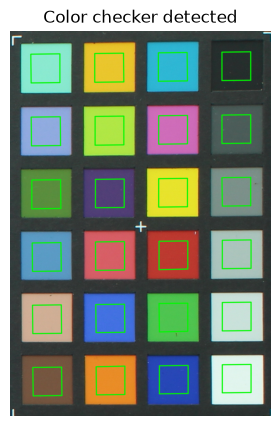

```python
path = "/Users/alejandra/Documents/traitly-tutorials/color_correction/cnj125643.jpg"
cc = ColorCorrection(path)
cc.load_image()
cc.detect_color_checker(plot = True)
```

Igual que antes, los colores se ven visiblemente más naturales e incluso el brillo de ambas imágenes corregidas ahora es comparable entre sí. Esto es especialmente útil cuando vamos a comparar imágenes con diferente iluminación, lo cual podría sesgar los resultados de color.

```
=================================================================
Correcting color, this may take a few seconds... ⋆✧｡٩(ˊᗜˋ)و✧*｡
```

[figure not shown]

```
Correction finished!
=================================================================
```

```python
cc.apply_color_correction(degree = 3,
                          num_components = 11,
                          plot_size = (12,12))
```

```python
cc.calculate_delta_e_stats(verbose = True)
```

```
-------------------------------------------------------
Mean ΔE before: 10.01
Mean ΔE after: 1.29
-------------------------------------------------------
Patch             | ΔE before | ΔE after | Diff
-------------------------------------------------------
A1: dark skin     |      4.81 |     0.94 |   3.88
B1: light skin    |     10.93 |     1.16 |   9.76
C1: blue sky      |     13.14 |     2.61 |  10.53
D1: foliage       |     13.46 |     0.89 |  12.57
E1: blue flower   |     15.63 |     2.10 |  13.53
F1: bluish green  |     11.28 |     0.78 |  10.50
A2: orange        |      6.61 |     1.23 |   5.38
B2: purplish blue |     11.05 |     1.56 |   9.48
C2: moderate red  |      5.79 |     0.50 |   5.29
D2: purple        |      6.08 |     0.49 |   5.59
E2: yellow green  |     10.57 |     0.12 |  10.45
F2: orange yellow |     12.56 |     1.03 |  11.53
A3: blue          |      5.70 |     0.81 |   4.89
B3: green         |     14.87 |     0.74 |  14.13
C3: red           |      4.53 |     0.12 |   4.40
D3: yellow        |      9.36 |     0.79 |   8.57
E3: magenta       |      9.51 |     0.55 |   8.96
F3: cyan          |     16.65 |     3.59 |  13.07
A4: white         |      7.80 |     2.39 |   5.40
B4: neutral 80    |     10.52 |     0.74 |   9.79
C4: neutral 65    |     12.76 |     2.44 |  10.32
D4: neutral 50    |     12.60 |     3.09 |   9.52
E4: neutral 35    |      8.37 |     1.10 |   7.27
F4: black         |      5.64 |     1.30 |   4.33
```

La corrección está pensada para imágenes tomadas con luz controlada, como las que se esperan en `FruitInternalAnalyzer` y `FruitExternalAnalyzer`. Sin embargo, también es posible corregir imágenes en otros contextos o tomadas al aire libre. La condición principal para que funcione bien es que el brillo de la tarjeta sea similar al brillo del resto de la imagen. Esto es necesario porque el modelo ajusta los valores LAB con base solo en la tarjeta y después aplica esa misma transformación a todos los píxeles de la imagen por igual.

Entonces, si la tarjeta es muy oscura y el fondo muy brillante, o viceversa, podemos tener malos resultados, como en la siguiente imagen. En la imagen corregida los colores de la tarjeta se ven bien y el delta E promedio es menor a 3, lo cual es bueno. Pero el resto de la imagen se ve sobreexpuesto. Esto pasa porque al aumentar el brillo de la tarjeta, se aumentó por igual el brillo del resto de la imagen. Lo importante a tener en cuenta aquí es que el delta E solo evalúa los parches, por eso no detecta este problema.

Seguimos trabajando en la clase `ColorCorrection`, por lo que esperamos incluir en el futuro modelos más adecuados para este tipo de situaciones.

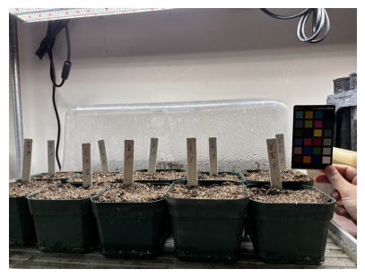

```
=======================================================
★ COLOR CARD:
=======================================================
> Color checker detected:
    - Coordinates: x1=4698, y1=1661, x2=5318, y2=2575
```

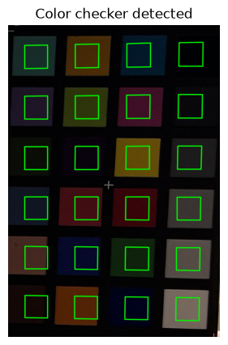

```
=================================================================
Correcting color, this may take a few seconds... ⋆✧｡٩(ˊᗜˋ)و✧*｡
```

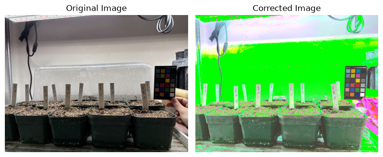

```
Correction finished!
=================================================================
-------------------------------------------------------
Mean ΔE before: 35.22
Mean ΔE after: 2.98
-------------------------------------------------------
Patch             | ΔE before | ΔE after | Diff
-------------------------------------------------------
A1: dark skin     |     26.99 |     2.89 |  24.10
B1: light skin    |     41.82 |     7.72 |  34.10
C1: blue sky      |     33.41 |     3.49 |  29.92
D1: foliage       |     32.38 |     5.51 |  26.88
E1: blue flower   |     37.78 |     3.70 |  34.08
F1: bluish green  |     52.00 |     1.06 |  50.94
A2: orange        |     39.04 |     1.10 |  37.94
B2: purplish blue |     27.81 |     1.08 |  26.73
C2: moderate red  |     30.74 |     2.08 |  28.65
D2: purple        |     25.41 |     4.01 |  21.40
E2: yellow green  |     50.72 |     0.80 |  49.92
F2: orange yellow |     50.63 |     2.09 |  48.54
A3: blue          |     23.56 |     1.88 |  21.69
B3: green         |     37.40 |     0.52 |  36.88
C3: red           |     26.83 |     1.20 |  25.64
D3: yellow        |     45.93 |     0.64 |  45.29
E3: magenta       |     31.77 |     0.84 |  30.93
F3: cyan          |     36.60 |     4.58 |  32.01
A4: white         |     39.50 |     1.69 |  37.81
B4: neutral 80    |     45.11 |     5.21 |  39.90
C4: neutral 65    |     42.23 |     5.98 |  36.25
D4: neutral 50    |     32.03 |     3.15 |  28.88
E4: neutral 35    |     22.82 |     5.08 |  17.73
F4: black         |     12.83 |     5.29 |   7.54
```

```python
cc = ColorCorrection("/Users/alejandra/Documents/traitly-tutorials/color_correction/IMG_6859.JPG")
cc.load_image()
cc.detect_color_checker(plot = True)
cc.apply_color_correction(plot = True)
cc.calculate_delta_e_stats(verbose = True)
```